# Post-hoc analyses of adaptation experiment

Sebastian Schuster

2/27/2018

### Catch trial performance

```
## [1] "Excluded 8 participants in might-biased condition."
```

```
## [1] "Excluded 11 participants in probably-biased condition."
```

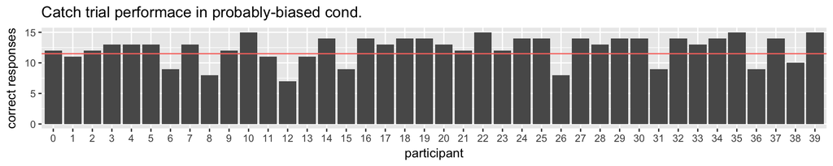

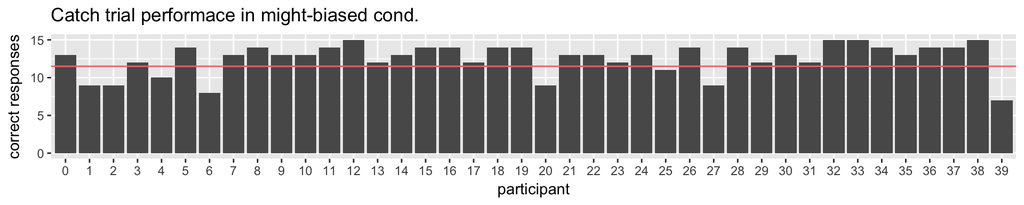

### Aggregated results

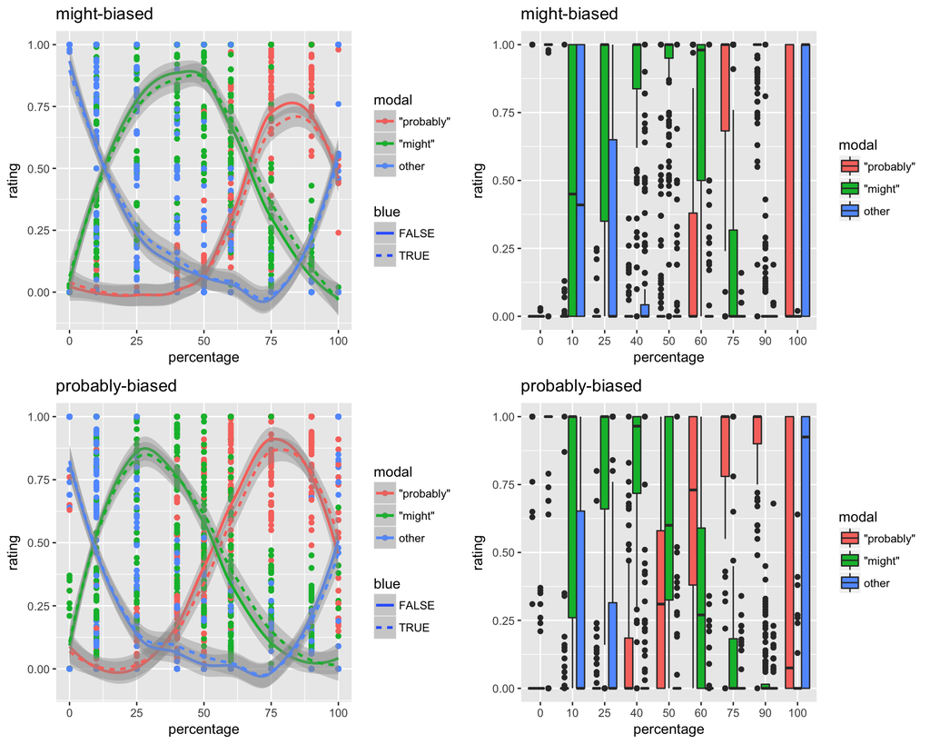

### AUC computation

#### Method 1

Here, we fit a linear model with natural cubic splines with 4 degrees of freedom to the might curve and the probably curve. We then, use this model to predict ratings in the interval $x=[0,100]$ with step size 0.1. Using these points, we use the `AUC` function with the `trapezoid` method to compute the AUC. This is very similar to what is done in Yildirim et al. (2015) except that we are using 4 df instead of 2, as this seems to lead to a better model fit (and given that we have 9 observations/participant, this is still not going to overfit).

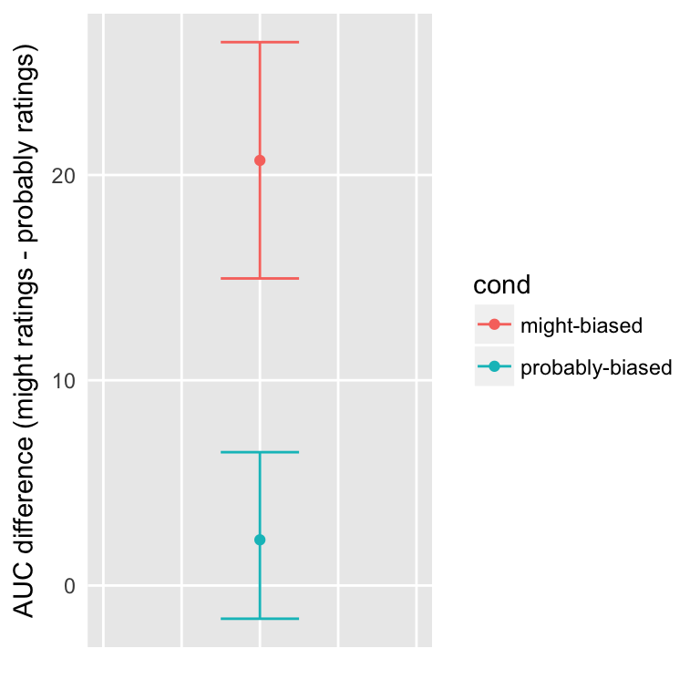

t-test:

```
##
##  Two Sample t-test
##
## data:  aucs.might$auc_diff and aucs.probably$auc_diff
## t = 4.9821, df = 59, p-value = 5.815e-06
## alternative hypothesis: true difference in means is not equal to 0
## 95 percent confidence interval:
##  11.06044 25.90845
## sample estimates:
## mean of x mean of y
## 20.711560  2.227117
```

#### Method 2

Here we simply use the `AUC` function with the `splines` method to directly compute the AUC.

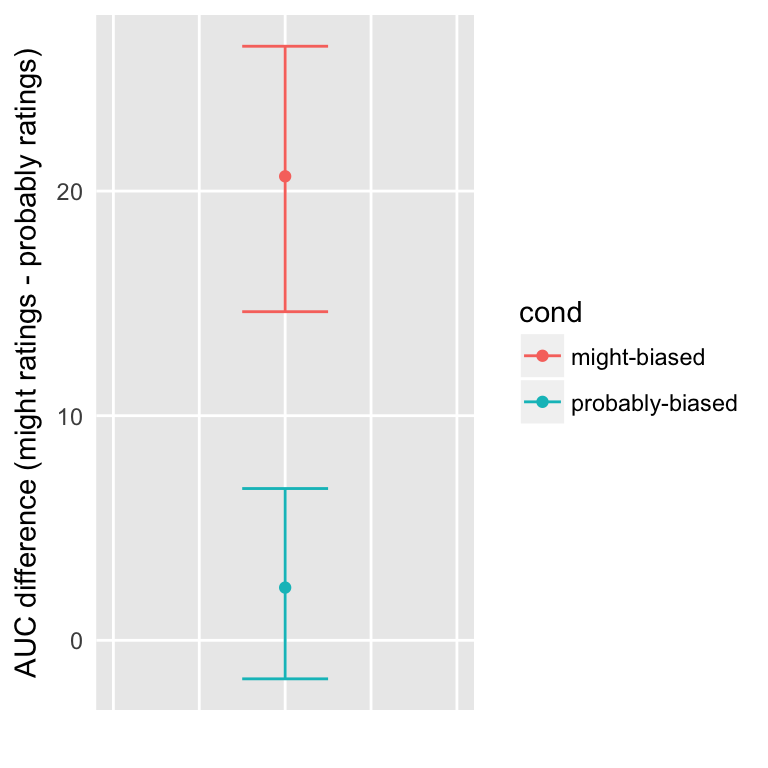

t-test:

```
##
##  Two Sample t-test
##
## data:  aucs.might$auc_diff and aucs.probably$auc_diff
## t = 4.9262, df = 59, p-value = 7.122e-06
## alternative hypothesis: true difference in means is not equal to 0
## 95 percent confidence interval:
##  10.87203 25.74610
## sample estimates:
## mean of x mean of y
## 20.656266  2.347203
```

```
##
## Cohen's d
##
## d estimate: 1.263 (large)
## 95 percent confidence interval:
##     lower     upper
## 0.7012653 1.8247340
```

## Analysis 2: Speaker gender differences?

### Catch trial performance

```
## [1] "Excluded 8 participants in might-biased condition."
```

```
## [1] "Excluded 11 participants in probably-biased condition."
```

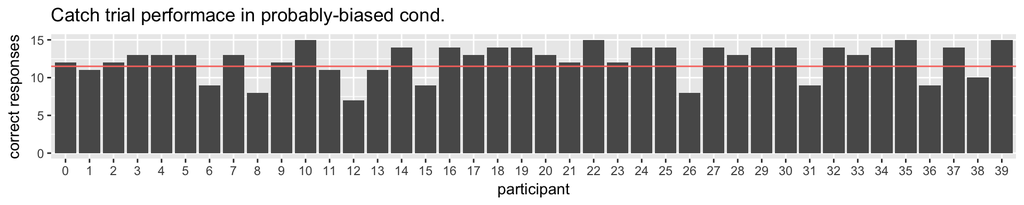

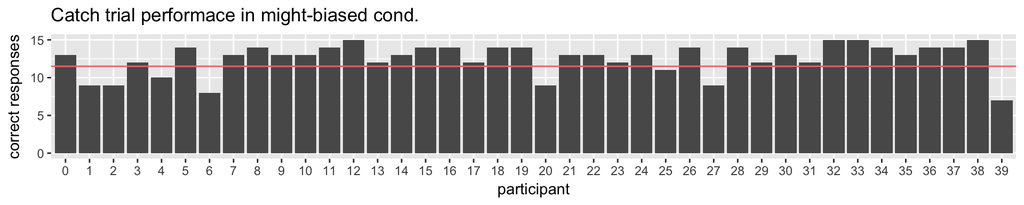

### Aggregated results

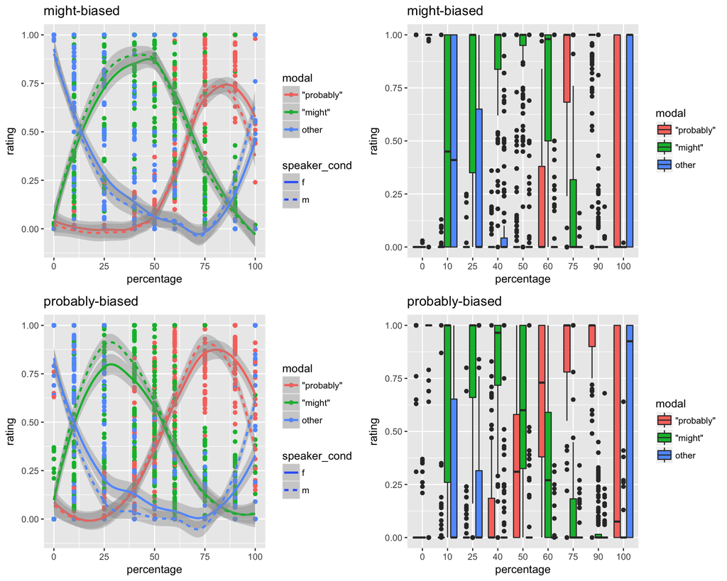

### AUC computation

#### Method 2

Here we simply use the `AUC` function with the `splines` method to directly compute the AUC.

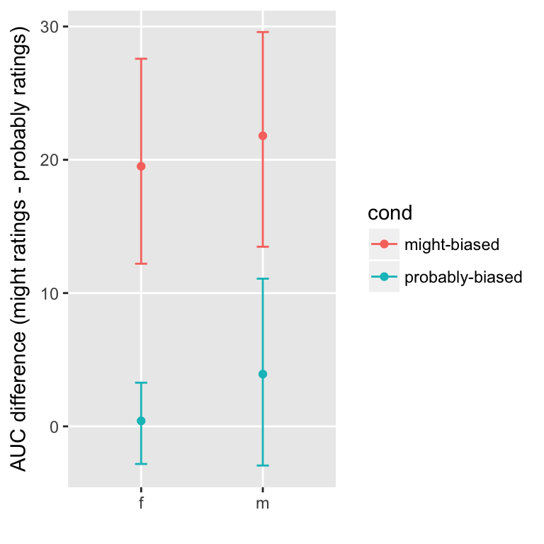

Linear model:

Difference between male and female speaker? Interactions?

```
##
## Call:
## lm(formula = auc_diff ~ speaker * cond, data = aucs.all)
##
## Residuals:
##     Min      1Q  Median      3Q     Max
## -42.715  -7.906  -0.781   8.674  37.301
##
## Coefficients:
##                              Estimate Std. Error t value Pr(>|t|)
## (Intercept)                    19.511      3.668   5.319 1.81e-06 ***
## speakerm                        2.291      5.187   0.442  0.66033
## condprobably-biased           -19.098      5.478  -3.486  0.00095 ***
## speakerm:condprobably-biased    1.214      7.544   0.161  0.87270
## ---
## Signif. codes:  0 '***' 0.001 '**' 0.01 '*' 0.05 '.' 0.1 ' ' 1
##
## Residual standard error: 14.67 on 57 degrees of freedom
## Multiple R-squared:  0.2989, Adjusted R-squared:  0.262
## F-statistic: 8.099 on 3 and 57 DF,  p-value: 0.0001396
```

Differences between male and female speaker in use of “other” for maximally certain?

```
##
## Call:
## lm(formula = rating_other ~ speaker_cond, data = d.might %>%
##     filter(., percentage_blue > 99))
##
## Residuals:
##     Min      1Q  Median      3Q     Max
## -0.8836  0.1164  0.1164  0.2436  0.2436
##
## Coefficients:
##               Estimate Std. Error t value Pr(>|t|)
## (Intercept)    0.75641    0.04702  16.086   <2e-16 ***
## speaker_condm  0.12719    0.06650   1.913   0.0581 .
## ---
## Signif. codes:  0 '***' 0.001 '**' 0.01 '*' 0.05 '.' 0.1 ' ' 1
##
## Residual standard error: 0.3762 on 126 degrees of freedom
## Multiple R-squared:  0.02821,    Adjusted R-squared:  0.0205
## F-statistic: 3.658 on 1 and 126 DF,  p-value: 0.05807
```

```
##
## Call:
## lm(formula = rating_other ~ speaker_cond, data = d.probably %>%
##     filter(., percentage_blue > 99))
##
## Residuals:
##     Min      1Q  Median      3Q     Max
## -0.8298 -0.2360  0.1702  0.1742  0.3965
##
## Coefficients:
##               Estimate Std. Error t value Pr(>|t|)
## (Intercept)    0.60346    0.05760   10.48  < 2e-16 ***
## speaker_condm  0.22638    0.07754    2.92  0.00423 **
## ---
## Signif. codes:  0 '***' 0.001 '**' 0.01 '*' 0.05 '.' 0.1 ' ' 1
##
## Residual standard error: 0.4153 on 114 degrees of freedom
## Multiple R-squared:  0.06957,    Adjusted R-squared:  0.06141
## F-statistic: 8.524 on 1 and 114 DF,  p-value: 0.004225
```